# Assignment 3

Mireille Vargas

Last compiled on 17 October, 2020

The following articles were used to decide on access to internet and ability to speak english well and its relationship with income: https://repository.library.georgetown.edu/bitstream/handle/10822/709850/Scott_georgetown_0076M_12514.pdf?sequence=1&isAllowed=y https://edsource.org/2017/many-children-whose-parents-speak-a-language-other-than-english-arent-enrolling-in-preschool/589062

```r
library(tidyverse)
```

```r
library(plotly)
library(sf)
library(tigris)
library(leaflet)
library("plyr")
library("dplyr")
library("readr")
library(censusapi)
library("rgdal")
library("sp")
library(zoo)
library(tidycensus)
library(corrplot)
# Add key to .Renviron
Sys.setenv(CENSUS_KEY= "dc599aed525530a3e2e60f900f08f7ff374a0c96")
# Reload .Renviron
readRenviron("C:/Users/mirei/OneDrive/Desktop/.Renviron")
# Check to see that the expected key is output in your R console
Sys.getenv("CENSUS_KEY")
```

```
## [1] "dc599aed525530a3e2e60f900f08f7ff374a0c96"
```

In the following chunk I am reading in the ACS data.

```r
acs_vars_2018_5yr <-
  listCensusMetadata(
    name = "2018/acs/acs5",
    type = "variables"
  )
```

Below I am reading in the PUMS data.

```r
pums_vars_2018 <-
  pums_variables %>%
  filter(year == 2018, survey == "acs5")
```

I created pums_vars_2018_distinct_hh to have a dataset that looks at the PUMS data specifically at the housing level.

```r
pums_vars_2018_distinct_hh <-
  pums_vars_2018 %>%
  distinct(var_code, var_label, data_type, level) %>%
  filter(level == "housing")
```

Now that I have my PUMS data, I will grab the specific data for ability to speak English, household income, and means of transportation using its corresponding var_code and limit the data to only include the Bay Area. Note: “means of transportation” and “ability to speak English” were calculated at the individual level as oppose to “household income” which was calculated at the household level.

```r
#census_api_key("c8aa67e4086b4b5ce3a8717f59faa9a28f611dab", install =TRUE)
ca_pums <- get_pums(
  variables = c(
    "PUMA",
    "NP",
    "JWTR", #Means of transportation which is at the person level
    "HINCP", #HOUSEHOLD INCOME
    "ENG" #Ability to speak English is at the person level
  ),
  state = "CA",
  year = 2018,
  survey = "acs5",
  recode = T
)
```

[output not shown]

[output cut: 28510 more lines]

[output not shown]

```r
ca_pumas <-
  pumas("CA", cb = T, progress_bar = F)

bay_county_names <-
  c(
    "Alameda",
    "Contra Costa",
    "Marin",
    "Napa",
    "San Francisco",
    "San Mateo",
    "Santa Clara",
    "Solano",
    "Sonoma"
  )

bay_counties <-
  counties("CA", cb = T, progress_bar = F) %>%
  filter(NAME %in% bay_county_names)

bay_pumas <-
  ca_pumas %>%
  st_centroid() %>%
  .[bay_counties, ] %>%
  st_set_geometry(NULL) %>%
  left_join(ca_pumas %>% select(GEOID10)) %>%
  st_as_sf()
```

```
## although coordinates are longitude/latitude, st_intersects assumes that they are planar
```

```
## although coordinates are longitude/latitude, st_intersects assumes that they are planar
```

```r
bay_pums <-
  ca_pums %>%
  filter(PUMA %in% bay_pumas$PUMACE10)
```

Since our “means of transportation” and “ability to speak English” are at the individual level, we will have to manipulate the data to have each respondent be part of a household as identified by SERIALNO (an automatic variable received through get_pums()).

```r
bay_pums_regression <-
  bay_pums %>%
  filter(SPORDER == 1) %>%
  mutate(
    walk_PublicTransport = ifelse(
      JWTR_label == "Bus or trolley bus" | JWTR_label == "Streetcar or trolley car (carro publico in Puerto Rico)" |  JWTR_label == "Subway or elevated" | JWTR_label == "Railroad" | JWTR_label == "Bicycle" | JWTR_label == "Walked", #not sure if I should include people who don't work
      1,
      0
    ),
    englishAbility = ifelse(
      ENG_label == "Well" | ENG_label == "Not well" | ENG_label == "Not at all",
      1,
      0
    )
  )
```

Now I will create the multivariate regression with the weights WGTP for households (in regards to the means of transportation).

```r
model_pums <- lm(HINCP ~ walk_PublicTransport + englishAbility, bay_pums_regression, weights = WGTP)

summary(model_pums)
```

```
##
## Call:
## lm(formula = HINCP ~ walk_PublicTransport + englishAbility, data = bay_pums_regression,
##     weights = WGTP)
##
## Weighted Residuals:
##      Min       1Q   Median       3Q      Max
## -1828802  -301452   -75613   131978 11443078
##
## Coefficients:
##                      Estimate Std. Error t value Pr(>|t|)
## (Intercept)          140327.5      390.5 359.309  < 2e-16 ***
## walk_PublicTransport  -6350.5     2328.3  -2.728  0.00638 **
## englishAbility       -57567.5      967.2 -59.521  < 2e-16 ***
## ---
## Signif. codes:  0 '***' 0.001 '**' 0.01 '*' 0.05 '.' 0.1 ' ' 1
##
## Residual standard error: 583900 on 138436 degrees of freedom
## Multiple R-squared:  0.025,  Adjusted R-squared:  0.02499
## F-statistic:  1775 on 2 and 138436 DF,  p-value: < 2.2e-16
```

For the ACS data, I want to specifically look at low income levels as my dependent variable. Articles have shown that the HUD now defines “low income” for a family of four in 2018 as those who make $117,400 in San Francisco, Marin, and San Mateo counties. In Santa Clara, making less than $94,000 is considered low income.  
For my analysis, I classified low-income levels as households that make less than 100k. Source: https://abc7news.com/finance/report-$117k-a-year-considered-low-income-in-some-bay-area-counties/3664989/

```r
bay_multiple_tract <-
  getCensus(
    name = "acs/acs5",
    vintage = 2018,
    region = "tract:*",
    regionin = "state:06+county:001,013,041,055,075,081,085,095,097", #specifies the bay area
    vars = c(
      "B19001_001E", #total household income
      "B19001_002E", #Estimate!!Total!!Less than $10,000
      "B19001_003E", #Estimate!!Total!!$10,000 to $14,999
      "B19001_004E", #Estimate!!Total!!$15,000 to $19,999
      "B19001_005E", #Estimate!!Total!!$20,000 to $24,999
      "B19001_006E", #Estimate!!Total!!$25,000 to $29,999
      "B19001_007E", #Estimate!!Total!!$30,000 to $34,999
      "B19001_008E", #Estimate!!Total!!$35,000 to $39,999
      "B19001_009E", #Estimate!!Total!!$40,000 to $44,999
      "B19001_010E", #Estimate!!Total!!$45,000 to $49,999
      "B19001_011E", #Estimate!!Total!!$50,000 to $59,999
      "B19001_012E", #Estimate!!Total!!$60,000 to $74,999
      "B19001_013E", #Estimate!!Total!!$75,000 to $99,999
      "B08119_028E", #Estimate!!Total!!Public transportation (excluding taxicab)
      "B08119_037E", #Estimate!!Total!!Walked
      "B08119_001E", #Estimate!!Total in regards to transportation
      "B16005F_011E", #Estimate!!Total!!Foreign born!!Speak another language!!Speak Enlgish less than very well
      "B16005F_006E", #Estimate!!Total!!Native!!Speak another language!!Speak English less than "very well"
      "B16005F_007E", #Estimate!!Total!!Foreign born
      "B16005F_002E" #Estimate!!Total!!Native
    )
  ) %>%
  transmute(
    tract = paste0(state, county, tract),
    perc_transp = (B08119_028E + B08119_037E) / B08119_001E, #CHANGE BECAUSE VALUES ARE LOW! SWITCHING TO TRANSPORTATION
    perc_under100k = (B19001_002E + B19001_003E + B19001_004E + B19001_005E + B19001_006E + B19001_007E + B19001_008E + B19001_009E + B19001_010E + B19001_011E + B19001_012E + B19001_013E) / B19001_001E,
    perc_noEnglish = (B16005F_011E + B16005F_006E) / (B16005F_007E + B16005F_002E)
  ) %>%
  filter(
    !is.na(perc_transp),
    !is.na(perc_under100k),
    !is.na(perc_noEnglish)
  )
```

Now I’ll create a correlation plot.

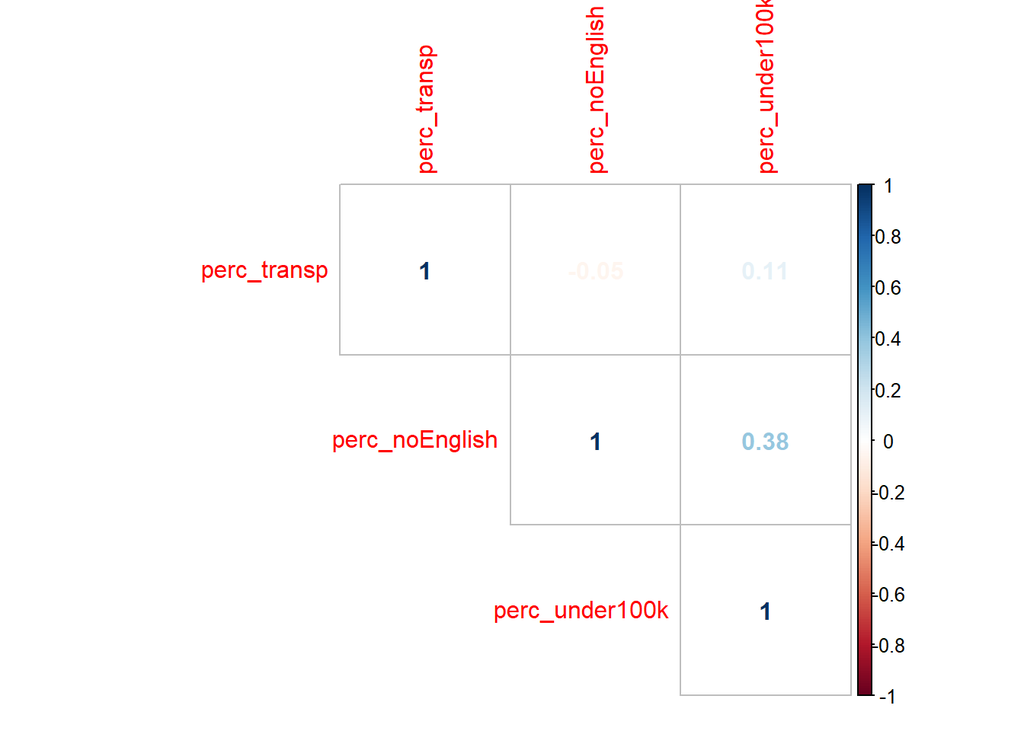

```r
correlationplot <- bay_multiple_tract %>%
  select(
    perc_transp,
    perc_noEnglish,
    perc_under100k
  ) %>%
  cor()

corrplot(
  correlationplot,
  method = "number",
  type = "upper"
)
```

Creating the multivariable regression.

```r
model <- lm(perc_under100k ~ perc_transp + perc_noEnglish, bay_multiple_tract)

summary(model)
```

```
##
## Call:
## lm(formula = perc_under100k ~ perc_transp + perc_noEnglish, data = bay_multiple_tract)
##
## Residuals:
##      Min       1Q   Median       3Q      Max
## -0.55354 -0.11546 -0.00841  0.11629  0.52415
##
## Coefficients:
##                Estimate Std. Error t value Pr(>|t|)
## (Intercept)    0.402657   0.008131  49.522  < 2e-16 ***
## perc_transp    0.148901   0.026774   5.561 3.15e-08 ***
## perc_noEnglish 0.332605   0.019913  16.703  < 2e-16 ***
## ---
## Signif. codes:  0 '***' 0.001 '**' 0.01 '*' 0.05 '.' 0.1 ' ' 1
##
## Residual standard error: 0.1649 on 1530 degrees of freedom
## Multiple R-squared:  0.1644, Adjusted R-squared:  0.1633
## F-statistic: 150.5 on 2 and 1530 DF,  p-value: < 2.2e-16
```

```r
pums_vars_2013 <-
  pums_variables %>%
  filter(year == 2013, survey == "acs5")
```

```r
ca_pums2013 <- get_pums(
  variables = c(
    "PUMA",
    "NP",
    "JWTR", #Means of transportation which is at the person level
    "HINCP", #HOUSEHOLD INCOME
    "ENG" #Ability to speak English is at the person level
  ),
  state = "CA",
  year = 2018,
  survey = "acs5",
  recode = T
)
```

[output not shown]

[output cut: 27498 more lines]

[output not shown]

```r
ca_pumas2013 <-
  pumas("CA", cb = T, progress_bar = F)

bay_county_names <-
  c(
    "Alameda",
    "Contra Costa",
    "Marin",
    "Napa",
    "San Francisco",
    "San Mateo",
    "Santa Clara",
    "Solano",
    "Sonoma"
  )

bay_counties <-
  counties("CA", cb = T, progress_bar = F) %>%
  filter(NAME %in% bay_county_names)

bay_pumas2013 <-
  ca_pumas2013 %>%
  st_centroid() %>%
  .[bay_counties, ] %>%
  st_set_geometry(NULL) %>%
  left_join(ca_pumas2013 %>% select(GEOID10)) %>%
  st_as_sf()
```

```
## although coordinates are longitude/latitude, st_intersects assumes that they are planar
```

```
## although coordinates are longitude/latitude, st_intersects assumes that they are planar
```

```r
bay_pums2013 <-
  ca_pums2013 %>%
  filter(PUMA %in% bay_pumas2013$PUMACE10)
```

```r
bay_pums_regression2013 <-
  bay_pums2013 %>%
  filter(SPORDER == 1) %>%
  mutate(
    walk_PublicTransport = ifelse(
      JWTR_label == "Bus or trolley bus" | JWTR_label == "Streetcar or trolley car (carro publico in Puerto Rico)" |  JWTR_label == "Subway or elevated" | JWTR_label == "Railroad" | JWTR_label == "Bicycle" | JWTR_label == "Walked", #not sure if I should include people who don't work
      1,
      0
    ),
    englishAbility = ifelse(
      ENG_label == "Well" | ENG_label == "Not well" | ENG_label == "Not at all",
      1,
      0
    )
  )
```

```r
model_pums2013 <- lm(HINCP ~ walk_PublicTransport + englishAbility, bay_pums_regression2013, weights = WGTP)

summary(model_pums2013)
```

```
##
## Call:
## lm(formula = HINCP ~ walk_PublicTransport + englishAbility, data = bay_pums_regression2013,
##     weights = WGTP)
##
## Weighted Residuals:
##      Min       1Q   Median       3Q      Max
## -1828802  -301452   -75613   131978 11443078
##
## Coefficients:
##                      Estimate Std. Error t value Pr(>|t|)
## (Intercept)          140327.5      390.5 359.309  < 2e-16 ***
## walk_PublicTransport  -6350.5     2328.3  -2.728  0.00638 **
## englishAbility       -57567.5      967.2 -59.521  < 2e-16 ***
## ---
## Signif. codes:  0 '***' 0.001 '**' 0.01 '*' 0.05 '.' 0.1 ' ' 1
##
## Residual standard error: 583900 on 138436 degrees of freedom
## Multiple R-squared:  0.025,  Adjusted R-squared:  0.02499
## F-statistic:  1775 on 2 and 138436 DF,  p-value: < 2.2e-16
```

ACS:

```r
bay_multiple_tract2013 <-
  getCensus(
    name = "acs/acs5",
    vintage = 2013,
    region = "tract:*",
    regionin = "state:06+county:001,013,041,055,075,081,085,095,097", #specifies the bay area
    vars = c(
      "B19001_001E", #total household income
      "B19001_002E", #Estimate!!Total!!Less than $10,000
      "B19001_003E", #Estimate!!Total!!$10,000 to $14,999
      "B19001_004E", #Estimate!!Total!!$15,000 to $19,999
      "B19001_005E", #Estimate!!Total!!$20,000 to $24,999
      "B19001_006E", #Estimate!!Total!!$25,000 to $29,999
      "B19001_007E", #Estimate!!Total!!$30,000 to $34,999
      "B19001_008E", #Estimate!!Total!!$35,000 to $39,999
      "B19001_009E", #Estimate!!Total!!$40,000 to $44,999
      "B19001_010E", #Estimate!!Total!!$45,000 to $49,999
      "B19001_011E", #Estimate!!Total!!$50,000 to $59,999
      "B19001_012E", #Estimate!!Total!!$60,000 to $74,999
      "B19001_013E", #Estimate!!Total!!$75,000 to $99,999
      "B08119_028E", #Estimate!!Total!!Public transportation (excluding taxicab)
      "B08119_037E", #Estimate!!Total!!Walked
      "B08119_001E", #Estimate!!Total in regards to transportation
      "B16005F_011E", #Estimate!!Total!!Foreign born!!Speak another language!!Speak Enlgish less than very well
      "B16005F_006E", #Estimate!!Total!!Native!!Speak another language!!Speak English less than "very well"
      "B16005F_007E", #Estimate!!Total!!Foreign born
      "B16005F_002E" #Estimate!!Total!!Native
    )
  ) %>%
  transmute(
    tract = paste0(state, county, tract),
    perc_transp = (B08119_028E + B08119_037E) / B08119_001E, #CHANGE BECAUSE VALUES ARE LOW! SWITCHING TO TRANSPORTATION
    perc_under100k = (B19001_002E + B19001_003E + B19001_004E + B19001_005E + B19001_006E + B19001_007E + B19001_008E + B19001_009E + B19001_010E + B19001_011E + B19001_012E + B19001_013E) / B19001_001E,
    perc_noEnglish = (B16005F_011E + B16005F_006E) / (B16005F_007E + B16005F_002E)
  ) %>%
  filter(
    !is.na(perc_transp),
    !is.na(perc_under100k),
    !is.na(perc_noEnglish)
  )
```

Creating the correlation plot.

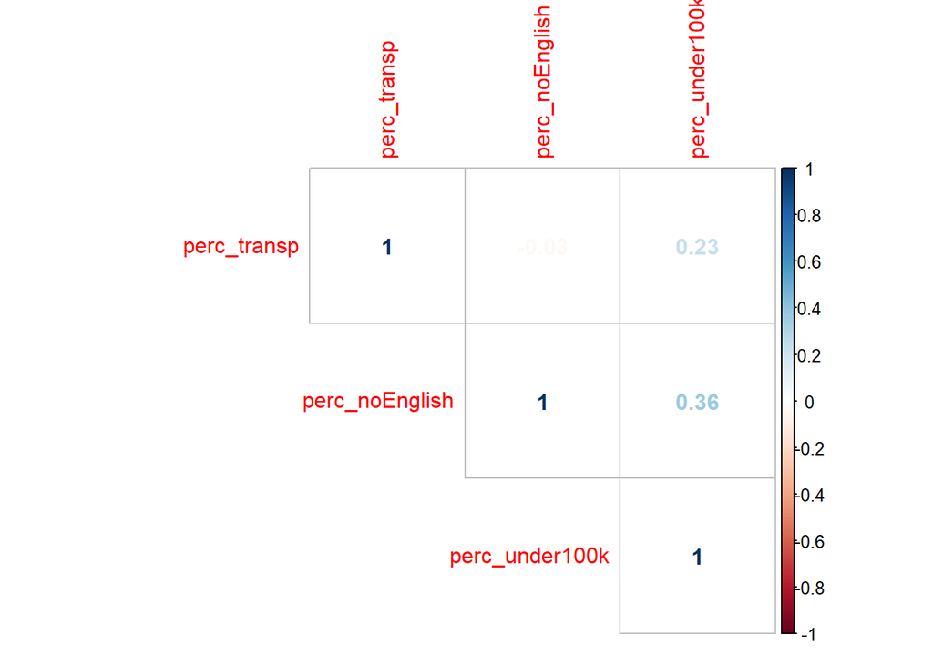

```r
correlationplot2013_tract <- bay_multiple_tract2013 %>%
  select(
    perc_transp,
    perc_noEnglish,
    perc_under100k
  ) %>%
  cor()

corrplot(
  correlationplot2013_tract,
  method = "number",
  type = "upper"
)
```

Creating the multivariate regression for 2013 tract data.

```r
model2013_tract <- lm(perc_under100k ~ perc_transp + perc_noEnglish, bay_multiple_tract2013)

summary(model2013_tract)
```

```
##
## Call:
## lm(formula = perc_under100k ~ perc_transp + perc_noEnglish, data = bay_multiple_tract2013)
##
## Residuals:
##      Min       1Q   Median       3Q      Max
## -0.57423 -0.11425  0.01142  0.12848  0.38692
##
## Coefficients:
##                Estimate Std. Error t value Pr(>|t|)
## (Intercept)    0.488976   0.007809   62.62   <2e-16 ***
## perc_transp    0.301997   0.028348   10.65   <2e-16 ***
## perc_noEnglish 0.290653   0.018089   16.07   <2e-16 ***
## ---
## Signif. codes:  0 '***' 0.001 '**' 0.01 '*' 0.05 '.' 0.1 ' ' 1
##
## Residual standard error: 0.1635 on 1514 degrees of freedom
## Multiple R-squared:  0.1923, Adjusted R-squared:  0.1912
## F-statistic: 180.2 on 2 and 1514 DF,  p-value: < 2.2e-16
```